# Part I - (Dataset Exploration Title)

### Data Cleaning

This section documents the basic cleaning of the dataset to prepare for further exploration and analysis

```python
# save a copy of the original data that contains only the variables to be analyzed and check out the first few entries on the DataFrame
data = dataOrig[toBeAnalyzed]
data.head().T
```

|  | 0 | 1 | 2 | 3 | 4 |
| --- | --- | --- | --- | --- | --- |
| Term | 36 | 36 | 36 | 36 | 36 |
| LoanStatus | Completed | Current | Completed | Current | Current |
| BorrowerRate | 0.158 | 0.092 | 0.275 | 0.0974 | 0.2085 |
| ProsperRating (numeric) | NaN | 6.0 | NaN | 6.0 | 3.0 |
| BorrowerAPR | 0.16516 | 0.12016 | 0.28269 | 0.12528 | 0.24614 |
| EmploymentStatus | Self-employed | Employed | Not available | Employed | Employed |
| IsBorrowerHomeowner | True | False | False | True | True |
| EstimatedEffectiveYield | NaN | 0.0796 | NaN | 0.0849 | 0.18316 |
| EstimatedLoss | NaN | 0.0249 | NaN | 0.0249 | 0.0925 |
| EstimatedReturn | NaN | 0.0547 | NaN | 0.06 | 0.09066 |
| LenderYield | 0.138 | 0.082 | 0.24 | 0.0874 | 0.1985 |
| Investors | 258 | 1 | 41 | 158 | 20 |
| CreditScoreRangeUpper | 659.0 | 699.0 | 499.0 | 819.0 | 699.0 |
| LoanOriginalAmount | 9425 | 10000 | 3001 | 10000 | 15000 |

```python
data.info()
```

```
<class 'pandas.core.frame.DataFrame'>
RangeIndex: 113937 entries, 0 to 113936
Data columns (total 14 columns):
 #   Column                   Non-Null Count   Dtype
---  ------                   --------------   -----
 0   Term                     113937 non-null  int64
 1   LoanStatus               113937 non-null  object
 2   BorrowerRate             113937 non-null  float64
 3   ProsperRating (numeric)  84853 non-null   float64
 4   BorrowerAPR              113912 non-null  float64
 5   EmploymentStatus         111682 non-null  object
 6   IsBorrowerHomeowner      113937 non-null  bool
 7   EstimatedEffectiveYield  84853 non-null   float64
 8   EstimatedLoss            84853 non-null   float64
 9   EstimatedReturn          84853 non-null   float64
 10  LenderYield              113937 non-null  float64
 11  Investors                113937 non-null  int64
 12  CreditScoreRangeUpper    113346 non-null  float64
 13  LoanOriginalAmount       113937 non-null  int64
dtypes: bool(1), float64(8), int64(3), object(2)
memory usage: 11.4+ MB
```

The dataset is observed to contain null values across several columns. This is as a result of the absence of data for loans that originated before July 2009. To simplify the analysis process, the loan entries are dropped so the dataset contains only loans that orignated after July 2009.

```python
data = data[data['ProsperRating (numeric)'].notnull()]
data.info()
```

```
<class 'pandas.core.frame.DataFrame'>
Int64Index: 84853 entries, 1 to 113936
Data columns (total 14 columns):
 #   Column                   Non-Null Count  Dtype
---  ------                   --------------  -----
 0   Term                     84853 non-null  int64
 1   LoanStatus               84853 non-null  object
 2   BorrowerRate             84853 non-null  float64
 3   ProsperRating (numeric)  84853 non-null  float64
 4   BorrowerAPR              84853 non-null  float64
 5   EmploymentStatus         84853 non-null  object
 6   IsBorrowerHomeowner      84853 non-null  bool
 7   EstimatedEffectiveYield  84853 non-null  float64
 8   EstimatedLoss            84853 non-null  float64
 9   EstimatedReturn          84853 non-null  float64
 10  LenderYield              84853 non-null  float64
 11  Investors                84853 non-null  int64
 12  CreditScoreRangeUpper    84853 non-null  float64
 13  LoanOriginalAmount       84853 non-null  int64
dtypes: bool(1), float64(8), int64(3), object(2)
memory usage: 9.1+ MB
```

```python
data.Term.unique()
```

```
array([36, 60, 12])
```

```python
print(data.EmploymentStatus.unique())
```

```
['Employed' 'Other' 'Full-time' 'Self-employed' 'Not employed' 'Retired'
 'Part-time']
```

```python
data.LoanStatus.value_counts()
```

```
Current                   56576
Completed                 19664
Chargedoff                 5336
Defaulted                  1005
Past Due (1-15 days)        806
Past Due (31-60 days)       363
Past Due (61-90 days)       313
Past Due (91-120 days)      304
Past Due (16-30 days)       265
FinalPaymentInProgress      205
Past Due (>120 days)         16
Name: LoanStatus, dtype: int64
```

```python
data.EmploymentStatus.value_counts()
```

```
Employed         67310
Full-time         7927
Self-employed     4538
Other             3806
Not employed       649
Retired            367
Part-time          256
Name: EmploymentStatus, dtype: int64
```

```python
# convert LoanStatus, ProsperRating (numeric), EmploymentStatus, Term into ordered categorical types
ordinalVarDict = {'LoanStatus': ['Chargedoff', 'Defaulted', 'Past Due (>120 days)', 'Past Due (91-120 days)', 'Past Due (61-90 days)', 'Past Due (31-60 days)', 'Past Due (16-30 days)', 'Past Due (1-15 days)', 'Current', 'FinalPaymentInProgress', 'Completed'],
                  'ProsperRating (numeric)': [1, 2, 3, 4, 5, 6, 7],
                  'EmploymentStatus': ['Other', 'Not employed', 'Retired', 'Part-time', 'Full-time', 'Employed', 'Self-employed'],
                  'Term': [12, 36, 60]
                 }
```

```python
for var in ordinalVarDict:

    orderedVar = pd.api.types.CategoricalDtype(ordered = True, categories = ordinalVarDict[var])
    data[var] = data[var].astype(orderedVar)
```

```python
# check the dataset to make sure the change made has been effected
data.info()
```

```
<class 'pandas.core.frame.DataFrame'>
Int64Index: 84853 entries, 1 to 113936
Data columns (total 14 columns):
 #   Column                   Non-Null Count  Dtype
---  ------                   --------------  -----
 0   Term                     84853 non-null  category
 1   LoanStatus               84853 non-null  category
 2   BorrowerRate             84853 non-null  float64
 3   ProsperRating (numeric)  84853 non-null  category
 4   BorrowerAPR              84853 non-null  float64
 5   EmploymentStatus         84853 non-null  category
 6   IsBorrowerHomeowner      84853 non-null  bool
 7   EstimatedEffectiveYield  84853 non-null  float64
 8   EstimatedLoss            84853 non-null  float64
 9   EstimatedReturn          84853 non-null  float64
 10  LenderYield              84853 non-null  float64
 11  Investors                84853 non-null  int64
 12  CreditScoreRangeUpper    84853 non-null  float64
 13  LoanOriginalAmount       84853 non-null  int64
dtypes: bool(1), category(4), float64(7), int64(2)
memory usage: 6.9 MB
```

```python
data.describe()
```

|  | BorrowerRate | BorrowerAPR | EstimatedEffectiveYield | EstimatedLoss | EstimatedReturn | LenderYield | Investors | CreditScoreRangeUpper | LoanOriginalAmount |
| --- | --- | --- | --- | --- | --- | --- | --- | --- | --- |
| count | 84853.000000 | 84853.000000 | 84853.000000 | 84853.000000 | 84853.000000 | 84853.000000 | 84853.000000 | 84853.000000 | 84853.000000 |
| mean | 0.196022 | 0.226658 | 0.168661 | 0.080306 | 0.096068 | 0.186017 | 68.264669 | 718.390240 | 9083.440515 |
| std | 0.074631 | 0.079916 | 0.068467 | 0.046764 | 0.030403 | 0.074631 | 95.195831 | 47.095937 | 6287.860058 |
| min | 0.040000 | 0.045830 | -0.182700 | 0.004900 | -0.182700 | 0.030000 | 1.000000 | 619.000000 | 1000.000000 |
| 25% | 0.135900 | 0.163280 | 0.115670 | 0.042400 | 0.074080 | 0.125900 | 1.000000 | 679.000000 | 4000.000000 |
| 50% | 0.187500 | 0.219450 | 0.161500 | 0.072400 | 0.091700 | 0.177500 | 32.000000 | 719.000000 | 7500.000000 |
| 75% | 0.257400 | 0.292540 | 0.224300 | 0.112000 | 0.116600 | 0.247400 | 97.000000 | 739.000000 | 13500.000000 |
| max | 0.360000 | 0.423950 | 0.319900 | 0.366000 | 0.283700 | 0.340000 | 1189.000000 | 899.000000 | 35000.000000 |

### What is/are the main feature(s) of interest in your dataset?

The main features of interest in the dataset are the BorrowerRate and the BorrowerAPR would like to find how other variables affect these variables.

### What features in the dataset do you think will help support your investigation into your feature(s) of interest?

Considering the already cleaned dataset, I expect that the BorrowerRate to be strongly related to the BorrowerAPR. Also, the EstimatedReturn and the EstimatedEffectiveYield are expected to be dependent on the BorrowerRate.

## Univariate Exploration

In this section, the distribution of individual variables are investigated. Unusual points and outliers are cleaned out to prepare for further analysis of the data.

The exploration will be started by checking distribution of the main variable of interest - borrower rates

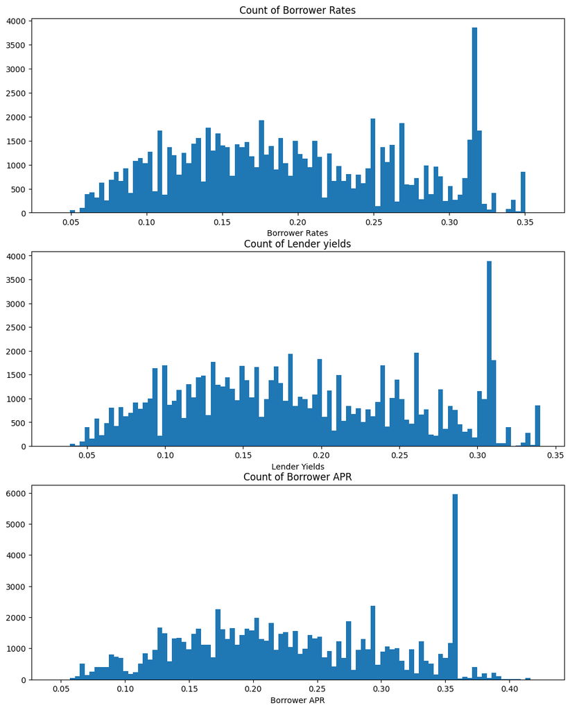

```python
# plot histogram of borrower rates, borrowerAPR and lender yield
plt.figure(figsize=[12, 15])

plt.subplot(3,1,1)
bins = 100
plt.title('Count of Borrower Rates')
plt.xlabel('Borrower Rates')
plt.hist(data=data, x='BorrowerRate', bins=bins)

plt.subplot(3,1,2)
bins = 100
plt.title('Count of Lender yields')
plt.xlabel('Lender Yields')
plt.hist(data=data, x='LenderYield', bins=bins)


plt.subplot(3,1,3)
bins = 100
plt.title('Count of Borrower APR')
plt.xlabel('Borrower APR')
plt.hist(data=data, x='BorrowerAPR', bins=bins);
```

Next I'll check out the counts of the different loan status value

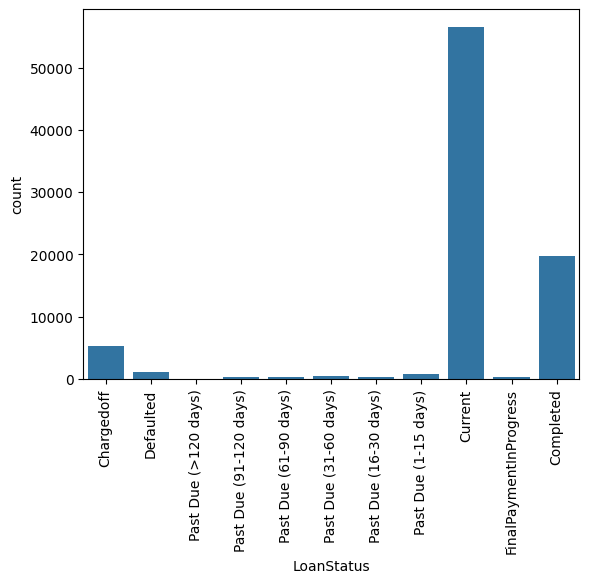

```python
# set default palette color and make count plot
defaultColor = sb.color_palette()[0]
sb.countplot(data=data, x='LoanStatus', color=defaultColor)
plt.xticks(rotation=90);
```

I'll now check out the loan terms and the IsBorrowerHomeowner column to check the spread of data in these columns

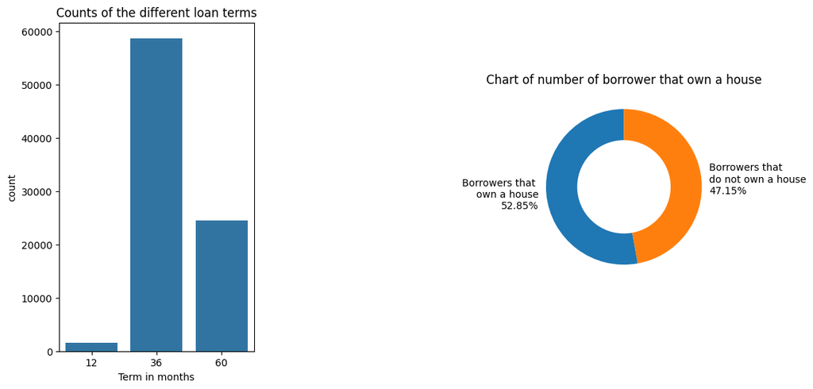

```python
# plot the counts of loan terms and the IsBorrowerHomeowner columns side by side
plt.figure(figsize=(12, 6))
plt.subplot(1, 3, 1)
plt.title('Counts of the different loan terms')
sb.countplot(data=data, x='Term', color=defaultColor)
plt.xlabel('Term in months')

plt.subplot(1, 3, 3)
x = data.IsBorrowerHomeowner.value_counts(normalize=True)
index = [('Borrowers that \nown a house\n{:.2f}%'.format(x[1]*100)),
         ('Borrowers that \ndo not own a house\n{:.2f}%'.format(x[0]*100))]
plt.title('Chart of number of borrower that own a house')
plt.pie(x, labels=index, startangle=90, wedgeprops = {'width': 0.4});
```

A great portion of the loans fall in the 36 months term period followed by the 60 months term and finally the 12 months term. The distribution of borrowers that are house owners and those that are not are somewhat evenly distributed.

The spread of data in the ProsperRating (numeric) and the EmploymentStatus columns are next checked to see if they hold any interesting properties

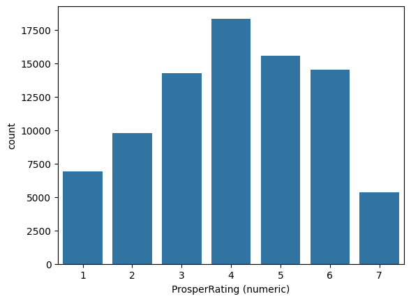

```python
sb.countplot(data=data, x='ProsperRating (numeric)', color=defaultColor);
```

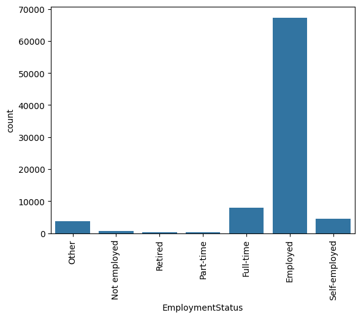

```python
sb.countplot(data=data, x='EmploymentStatus', color=defaultColor);
plt.xticks(rotation=90);
```

The distribution of the ProsperRating (numeric) is unimodal with the score 4 occuring most frequently. On the other hand the majority of the borrowers are employed with a significant portion of them been full-time workers and self-employed.

The univariate exploration is then continued by checking out the distribution of EstimatedEffectiveYield, EstimatedReturn and EstimatedLoss next to each other.

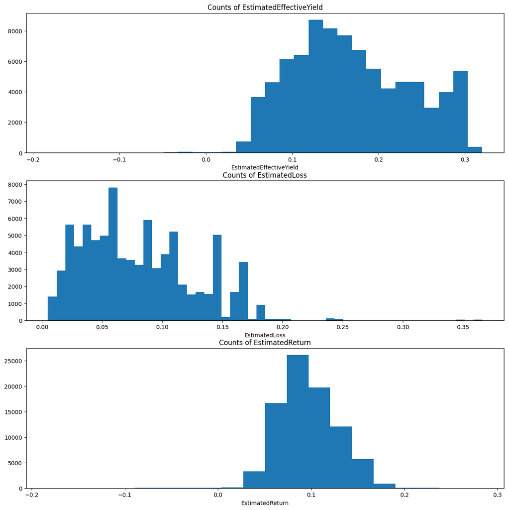

```python
# plot the diagrams of the 3 histograms over each other
plt.figure(figsize=[15,15])
plt.subplot(3, 1, 1)
bins = 30
plt.title('Counts of EstimatedEffectiveYield')
plt.xlabel('EstimatedEffectiveYield')
plt.hist(data=data, x='EstimatedEffectiveYield', bins=bins)

plt.subplot(3, 1, 2)
bins = 50
plt.title('Counts of EstimatedLoss')
plt.xlabel('EstimatedLoss')
plt.hist(data=data, x='EstimatedLoss', bins=bins)

plt.subplot(3, 1, 3)
bins = 20
plt.title('Counts of EstimatedReturn')
plt.xlabel('EstimatedReturn')
plt.hist(data=data, x='EstimatedReturn', bins=bins);
```

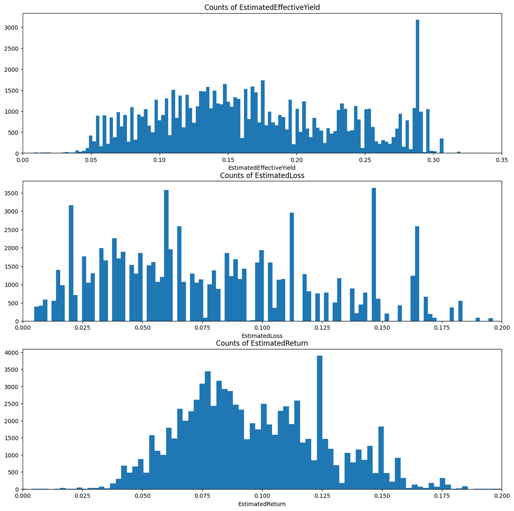

```python
# increasing the amount of bins across the plots and also scaling the data to better view the most
# significant portion of the distributions over each other
plt.figure(figsize=[15,15])
plt.subplot(3, 1, 1)
bins = 200
plt.title('Counts of EstimatedEffectiveYield')
plt.xlabel('EstimatedEffectiveYield')
plt.hist(data=data, x='EstimatedEffectiveYield', bins=bins)
plt.xlim(0, 0.35)

plt.subplot(3, 1, 2)
bins = 200
plt.title('Counts of EstimatedLoss')
plt.xlabel('EstimatedLoss')
plt.hist(data=data, x='EstimatedLoss', bins=bins)
plt.xlim(0, 0.2)

plt.subplot(3, 1, 3)
bins = 200
plt.title('Counts of EstimatedReturn')
plt.xlabel('EstimatedReturn')
plt.hist(data=data, x='EstimatedReturn', bins=bins)
plt.xlim(0, 0.2);
```

The estimated values are seen to have a significant amount amount of outliers, with both the EstimatedEffectiveYield and the EstimatedReturn having extreme values almost up to -0.2. The distribution of the EstimatedLoss is seen to contain lots of gaps in the distribution and also numerous frequency spikes. This suggests that the estimations may have been rounded to some other values

Next up, I'll check out the distribution of the LoanOriginalAmount and Investors columns to determine their general properties.

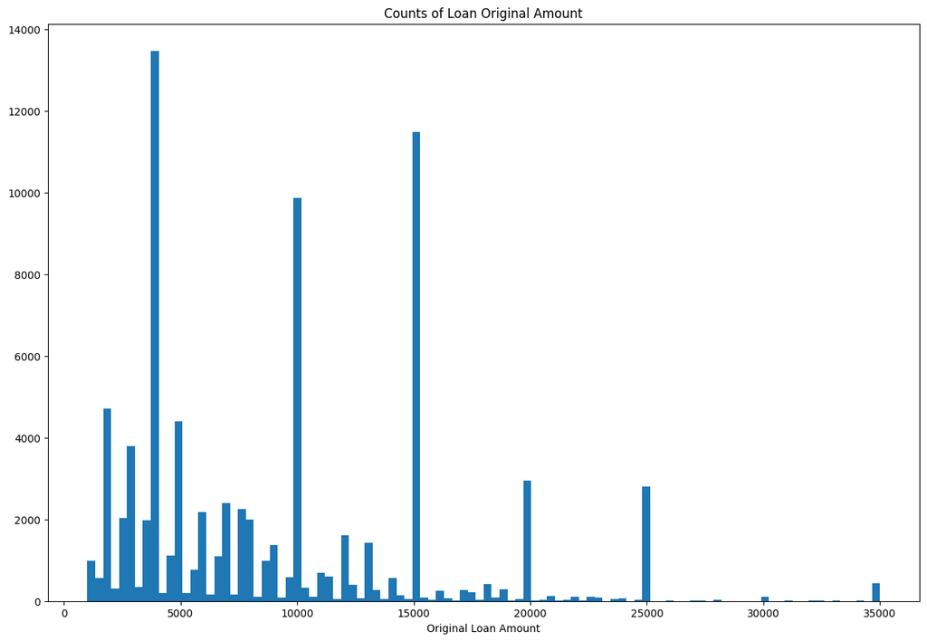

```python
plt.figure(figsize=[15,10])
bins = 100
plt.title('Counts of Loan Original Amount')
plt.xlabel('Original Loan Amount')
plt.hist(data=data, x='LoanOriginalAmount', bins=bins);
```

I'll continue by moving on to visualize the distribution of the Investors

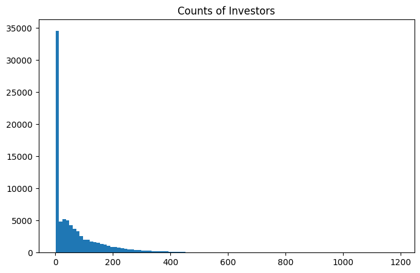

```python
bins = 100
plt.figure(figsize=[8, 5])
plt.title('Counts of Investors')
plt.hist(data=data, x='Investors', bins=bins);
```

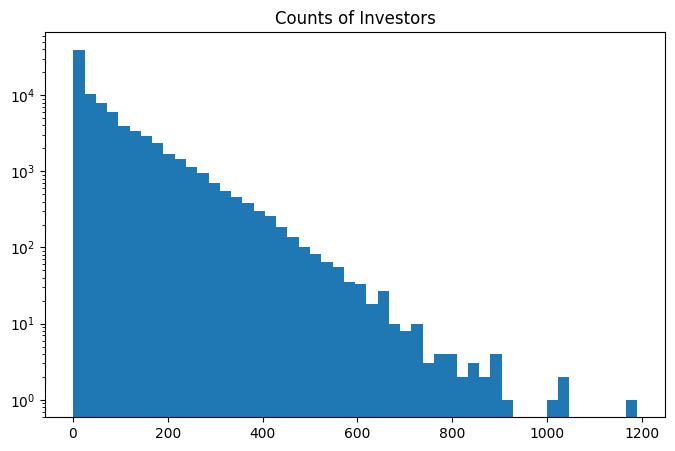

```python
# the distribution is seen to have a long tail, let's have the counts on a logarithmic scale
bins = 50
plt.figure(figsize=[8, 5])
plt.title('Counts of Investors')
plt.hist(data=data, x='Investors', bins=bins)
plt.yscale('log');
```

Finally, I'll check out the distribution of CreditScoreRangeUpper

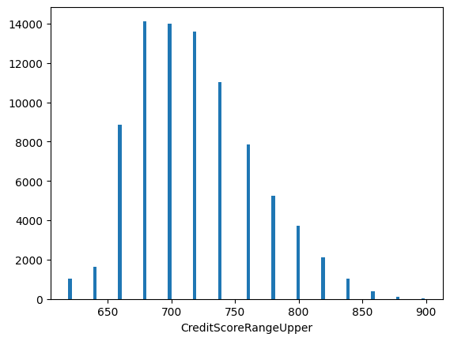

```python
bins = 100
plt.xlabel('CreditScoreRangeUpper')
plt.hist(data=data, x='CreditScoreRangeUpper', bins=bins);
```

From the figure above the distribution of CreditScoreRangeUpper follows an approximately normal distribution. The plot also shows that the CreditScoreRangeUpper values are discrete rather than been continous.

### Discuss the distribution(s) of your variable(s) of interest. Were there any unusual points? Did you need to perform any transformations?

The distribution of the borrower rate is relatively uneven with a lot of frequency spikes that were observed in the distribution. The BorrowerAPR showed a distribution that was relatively similar to that of the BorrowerRate with frequency spikes occuring at similar positions.

### Of the features you investigated, were there any unusual distributions? Did you perform any operations on the data to tidy, adjust, or change the form of the dataOrig? If so, why did you do this?

The data for the number of investors showed a great variation in count with some of the count of this variable been several orders of magnitude greater than the others. For this reason, the y-axis of the histogram of the investors was plotted on a logarithmic scale. Also the null values in most of the columns were dropped since most of them occured as result of the absence of data earlier than July 2009. This was done so as to simplify the process of the exploration and analysis of the data.

## Bivariate Exploration

To begin, I want to look at the correlations between the numerical variables in the data

```python
# check  the columns of the data
data.columns
```

```
Index(['Term', 'LoanStatus', 'BorrowerRate', 'ProsperRating (numeric)',
       'BorrowerAPR', 'EmploymentStatus', 'IsBorrowerHomeowner',
       'EstimatedEffectiveYield', 'EstimatedLoss', 'EstimatedReturn',
       'LenderYield', 'Investors', 'CreditScoreRangeUpper',
       'LoanOriginalAmount'],
      dtype='object')
```

```python
# separate the categorical variables from numerical ones
catVars = ['Term', 'LoanStatus','ProsperRating (numeric)', 'EmploymentStatus']
numericVars = ['BorrowerRate', 'BorrowerAPR', 'EstimatedEffectiveYield', 'Investors', 'LenderYield',
               'EstimatedLoss', 'EstimatedReturn', 'LoanOriginalAmount', 'CreditScoreRangeUpper'
              ]
```

```python
# check the correlation between the numerical variables
data[numericVars].corr()
```

|  | BorrowerRate | BorrowerAPR | EstimatedEffectiveYield | Investors | LenderYield | EstimatedLoss | EstimatedReturn | LoanOriginalAmount | CreditScoreRangeUpper |
| --- | --- | --- | --- | --- | --- | --- | --- | --- | --- |
| BorrowerRate | 1.000000 | 0.993333 | 0.895282 | -0.242281 | 0.999996 | 0.945297 | 0.817670 | -0.413466 | -0.508681 |
| BorrowerAPR | 0.993333 | 1.000000 | 0.895635 | -0.264991 | 0.993334 | 0.949538 | 0.794275 | -0.426361 | -0.525888 |
| EstimatedEffectiveYield | 0.895282 | 0.895635 | 1.000000 | -0.265244 | 0.895343 | 0.798135 | 0.801568 | -0.327266 | -0.445127 |
| Investors | -0.242281 | -0.264991 | -0.265244 | 1.000000 | -0.242326 | -0.275501 | -0.092337 | 0.319235 | 0.349837 |
| LenderYield | 0.999996 | 0.993334 | 0.895343 | -0.242326 | 1.000000 | 0.945308 | 0.817654 | -0.413422 | -0.508695 |
| EstimatedLoss | 0.945297 | 0.949538 | 0.798135 | -0.275501 | 0.945308 | 1.000000 | 0.591056 | -0.429890 | -0.511263 |
| EstimatedReturn | 0.817670 | 0.794275 | 0.801568 | -0.092337 | 0.817654 | 0.591056 | 1.000000 | -0.286118 | -0.346233 |
| LoanOriginalAmount | -0.413466 | -0.426361 | -0.327266 | 0.319235 | -0.413422 | -0.429890 | -0.286118 | 1.000000 | 0.277918 |
| CreditScoreRangeUpper | -0.508681 | -0.525888 | -0.445127 | 0.349837 | -0.508695 | -0.511263 | -0.346233 | 0.277918 | 1.000000 |

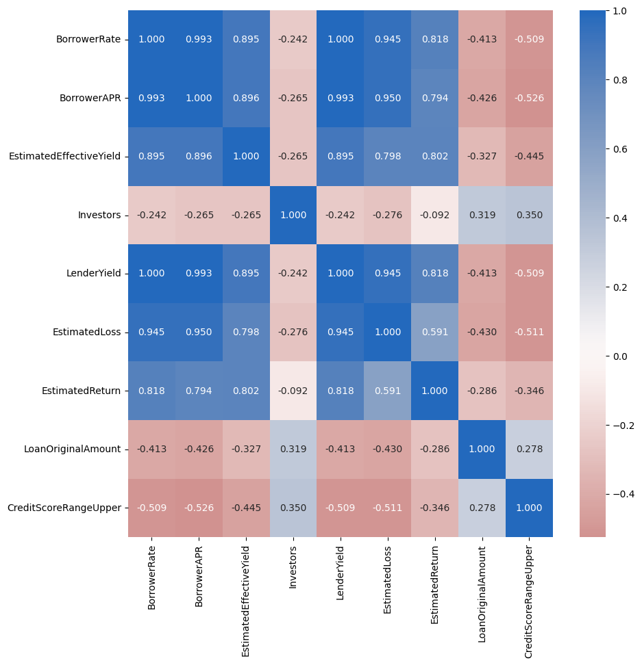

```python
plt.figure(figsize=[10, 10])
sb.heatmap(data[numericVars].corr(), annot=True, fmt='.3f', cmap='vlag_r', center=0);
```

```python
# create a dummy dataframe containing only 500 random entries from the dataset to be used for further analysis
dataSample = data.sample(500, random_state=42)
```

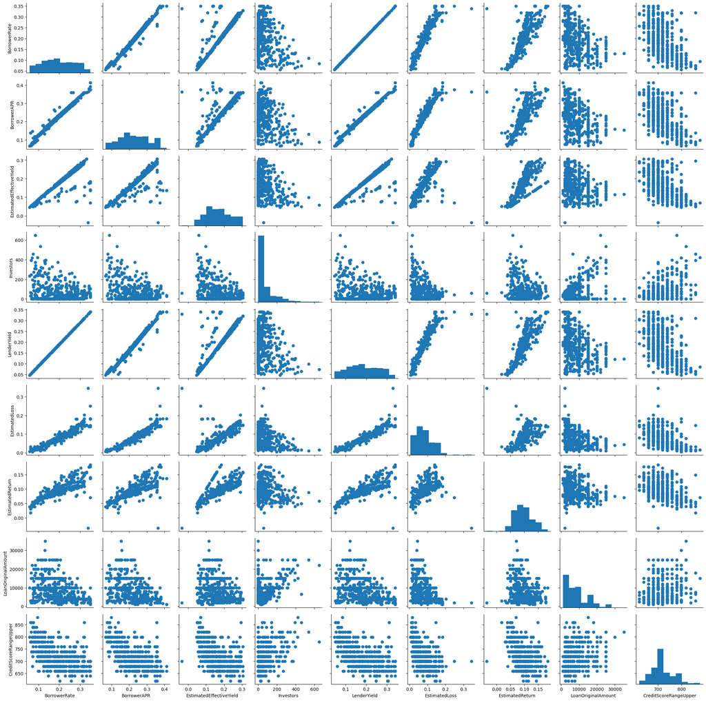

```python
# create plot matrix using the dataframe initially created that contains 500 entries
g = sb.PairGrid(data=dataSample, vars=numericVars)
g.map_diag(plt.hist)
g.map_offdiag(plt.scatter);
```

From the plot, the BorrowerRate and the BorrowerAPR are highly positively correlated which was already expected. Similarly the LenderYield is strongly positively correlated with both the BorrowerRate as well as the BorrowerAPR, this suggests that the lender yield is dependent on the value of either of the BorrowerRate and the BorrowerAPR or even both of them.

Also, the EstimatedReturn and the EstimatedLoss both show an approximately non-linear relationship with both the BorrowerRate and the BorrowerAPR. On the other hand, Investors is seen to be slightly negatively correlated to both the BorrowerRate and BorrowerAPR. For the CreditScoreRangeUpper, although it takes on discrete values, a non-linear relationship is observed between this variable and the BorrowerAPR as well as BorrowerRate.

The LoanOriginalAmount shows little correlation with other variables but a slight negative correlation may be observed between this variable and the EstimatedLoss, while a slight positive correlation may be observed between this variable and the Investors.